# Raport_Projet_AcLab

Dahiez Burdy

20/05/2021

# Introduction

Sur ce tp, nous allons annalyser des données météo enregistré par une sonde météorologique conçu par la filière IOT Maker, ces données sont constitué, de la date et heure, l’humidité, pression, temperature, intensité lumineuse et la pluie.avec ces données nous allons étudier quelles sont les facteurs qui annoncent la pluie. comme par exemple si le taux d’humidité augmente avant qu’il pleuve.

- Hypothèse :

Nous émetons l’hypothèse que la diminution de pression est un facteur annonciateur de la pluie.

Nous émetons l’hypothèse que le facteur d’humidité est un facteur annonciateur de la pluie plus conséquent selon la saison.

Nous émetons l’hypothèse que la température diminue avant l’arrivé de la pluie.

Nous émetons l’hypothèse que si nous detectons la présence de la pluie moins de 10 minutes avant la prédiction, la probabilitée qu’il pleuve augmente.

Nous émétons l’hypothèse que la nuit est un facteur annonciateur de la pluie.

Est il possible de creer un algorythme de prédiction d’apparition de la pluie ayant une precision de plus de 0.8 ?

# Analyse de la Pression

Pour etre sûr que cette hypothése est intéréssante nous allons recherché la corrélation entre la Pression atmosphérique et l’apparition de pluie .Nous voulons déja savoir si la temperature à une corrélation avec la pressions athmosphérique . Pour ce faire nous executons ces commandes suivantes :

```r
cor.test(data_meteo$pressure , data_meteo$temperature) #-0.31
```

```
##
##  Pearson's product-moment correlation
##
## data:  data_meteo$pressure and data_meteo$temperature
## t = -90.622, df = 72255, p-value < 2.2e-16
## alternative hypothesis: true correlation is not equal to 0
## 95 percent confidence interval:
##  -0.3259972 -0.3129026
## sample estimates:
##        cor
## -0.3194652
```

```r
data_meteo_season$hour <- strtoi(str_sub(data_meteo_season$date..date, 13, 14))

data_meteo_jour<- filter(data_meteo_season , hour >=  7)

data_meteo_jour <-  filter(data_meteo_jour , hour <=  21)
```

On observe que de 8 a 10 heures les données ne sont pas traitées par problème de selection dans R studio .

Maintenant on vas observer la correlation entre la pression et la pluie pour une journée les de 7 heure à 21 heures

```r
cor.test(data_meteo_jour$pressure , data_meteo_jour$rain) #-0.07924169
```

```
##
##  Pearson's product-moment correlation
##
## data:  data_meteo_jour$pressure and data_meteo_jour$rain
## t = -15.425, df = 42047, p-value < 2.2e-16
## alternative hypothesis: true correlation is not equal to 0
## 95 percent confidence interval:
##  -0.08451056 -0.06550187
## sample estimates:
##         cor
## -0.07501303
```

On observe ici une très légére correlation négative , est un p-value très faible . Nous en déduisons donc que l’analyse de l’évolution de la préssion athmosphérique ne peut pas nous permettre de determiner fiablement si la pluie risque de tomber dans l’heure .

Pour confirmer graphiquement que la Pression athmosphérique n’est pas un bon indicateur nous avons extrait les données se trouvant juste avant une période de pluie . Pour faire plus simple nous selectionnons les données se trouvant entre chaque péridode de pluie grace un un code python.

```r
#path_to_python <- "C:/Python39/python.exe"
#use_python(path_to_python, required = TRUE)
# C:\\Users\\sburd\\OneDrive\\Bureau\\Semestre2\\Projet_Data\Stat\\Stat_Projet_Data\\RecupPluieTrue.py
py_install("pandas")

source_python("C:\\Users\\sburd\\OneDrive\\Bureau\\Semestre2\\Projet_Data\\Stat\\Stat_Projet_Data\\RecupPluieTrue.py")
#monCsv <- openMonCsv("C:\\Users\\sburd\\OneDrive\\Bureau\\Semestre2\\Projet_Data\\DataV2\\dataTrainSortiPluie1.csv")
monCsv <- openMonCsv("C:\\Users\\sburd\\OneDrive\\Bureau\\Semestre2\\Projet_Data\\DataV2\\dataTrainSorti.csv")
heureAdd <- AddHour(monCsv)
maTabPluie <- trie(heureAdd)
tabDataFrame <- SubsetData(maTabPluie)
newCollection <- TrieTaille(120,180,tabDataFrame , heureAdd)
```

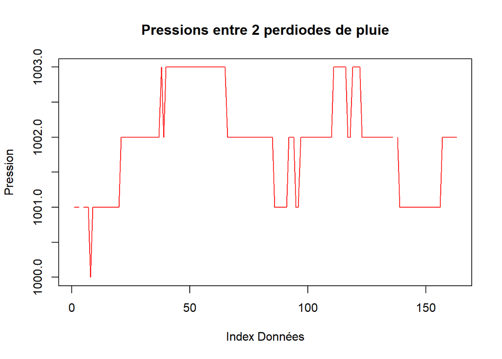

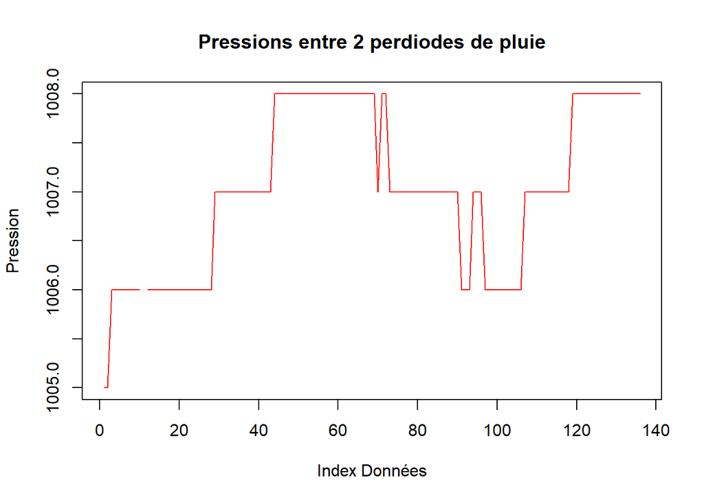

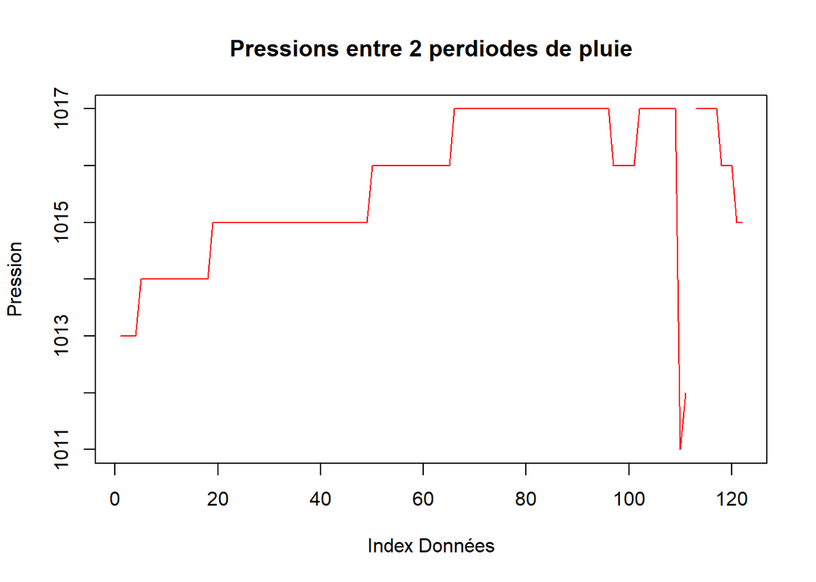

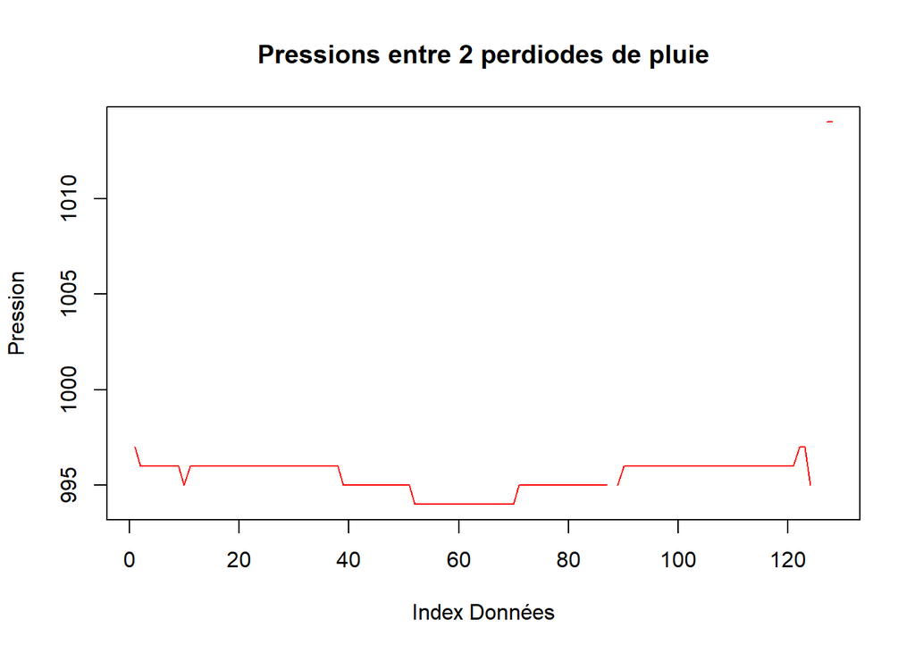

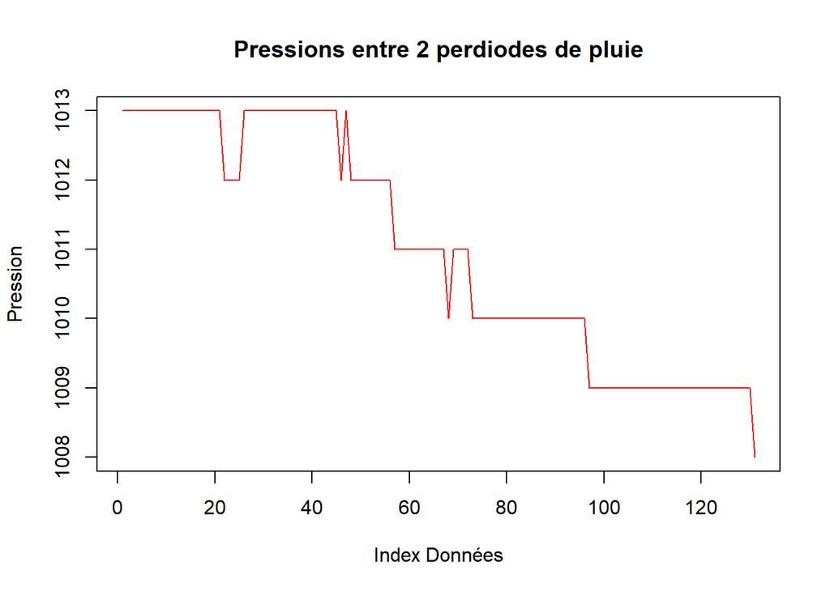

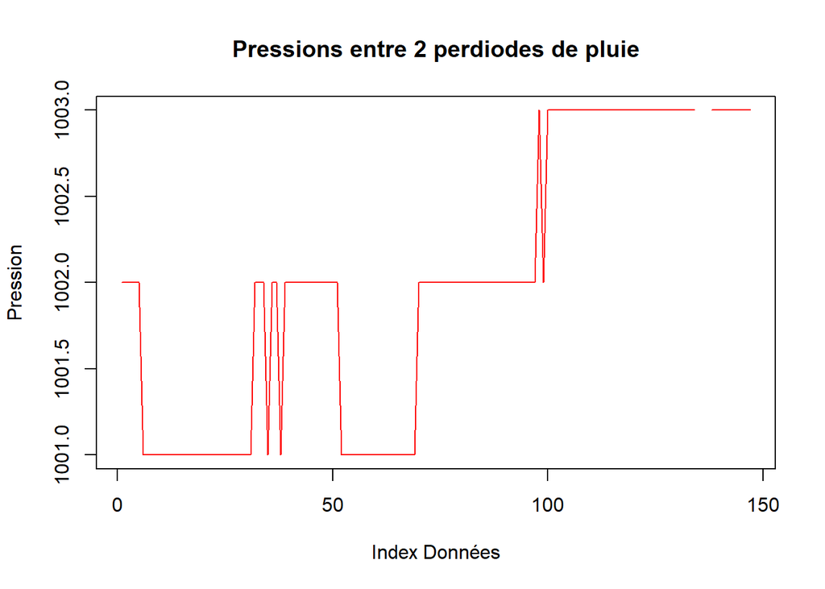

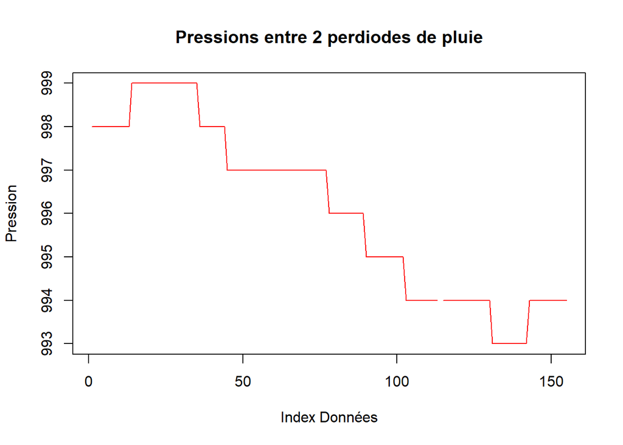

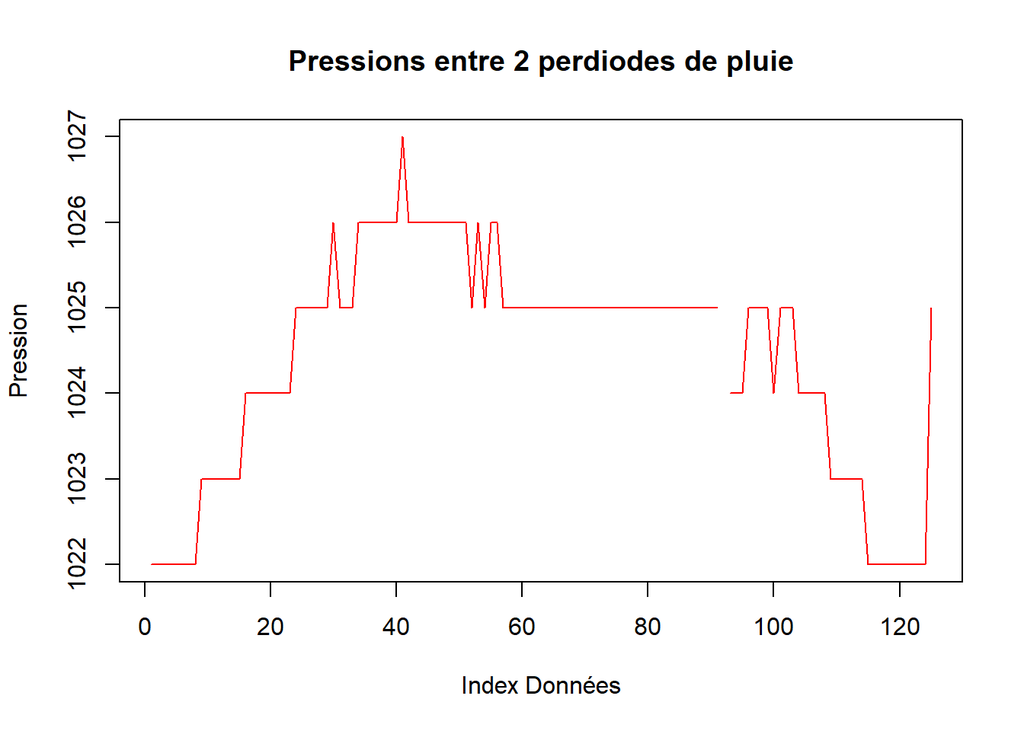

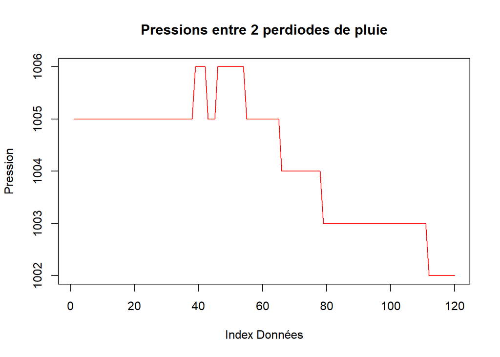

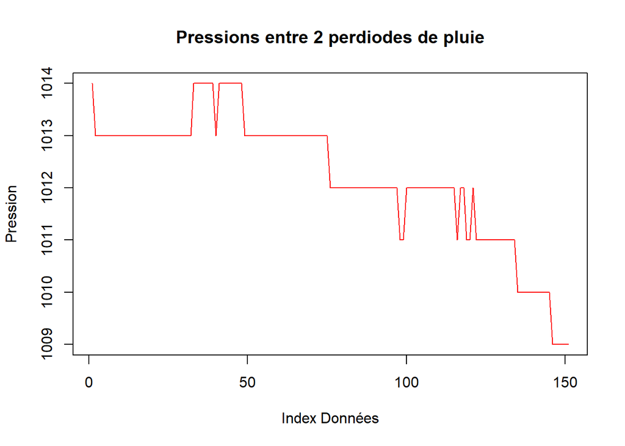

Dans l’objective nous voudrions voir une augmentation ou une diminution de clair de la pression pouvant nous permettre de prédire la pluie sans trop de risuqe de ce tromper. Ces graphiques montre bien la très faible corrélation trouvé ci dessus.

# Analyse de la température :

Toujour dans le même objectif de trouver une variable présentant une forte corrélation avec la varibale pluie, nous décidons maintenant d’observer la corelation entre la température et la pluie.

Pour limiter les variation de température lié au cycle jour / nuit du soleil nous décidons de traiter des données effectué entre 7:00 heure et 21:00 heures.

```r
cor.test(data_meteo_jour$temperature , data_meteo_jour$rain)
```

```
##
##  Pearson's product-moment correlation
##
## data:  data_meteo_jour$temperature and data_meteo_jour$rain
## t = -51.184, df = 38867, p-value < 2.2e-16
## alternative hypothesis: true correlation is not equal to 0
## 95 percent confidence interval:
##  -0.2605810 -0.2419536
## sample estimates:
##        cor
## -0.2512906
```

on observe une corrélation négative relativement forte entre la temperature et la présense de pluie , ce qui semble logique , la pluis diminue forcément la température extérieure .

```r
#
# for (elem in newCollection){
#
#
#     plot( elem[" temperature"], main="temperature  entre 2 perdiodes de pluie",
#           ylab="Temperature ( en degré ° )",
#           xlab="Index Données",
#           type="l",
#           col="blue"  )
#
#
# }
```

# Analyse de l’humidité :

Nous pensons que l’humidité doit être croissante avant l’arrivé de la pluie . Nous cherchons tout d’abord à s’avoir si une correlation existe entre l’humidité et la quantité de Pluie. Toujours limiter les variation d’humidité lié au cycle jour / nuit du soleil et de la rosée nous décidons de traiter des données effectué entre 7:00 heure et 21:00 heures.

```r
cor.test(data_meteo_jour$humidity , data_meteo_jour$rain)# 0.30
```

```
##
##  Pearson's product-moment correlation
##
## data:  data_meteo_jour$humidity and data_meteo_jour$rain
## t = 65.671, df = 41922, p-value < 2.2e-16
## alternative hypothesis: true correlation is not equal to 0
## 95 percent confidence interval:
##  0.2967093 0.3140684
## sample estimates:
##       cor
## 0.3054142
```

On observe étonnament une corrélation plus faible que nous ne le pensions entre la pluie et le pourcentage d’humidité . Nous nous attendions à trouver un corélation positive et très élévé .

Nous allons donc observer les graphs sur les quelques échantillons correspondants.

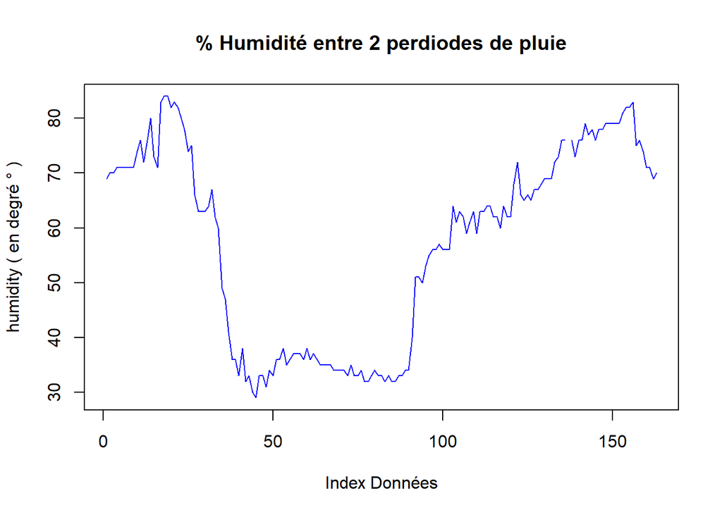

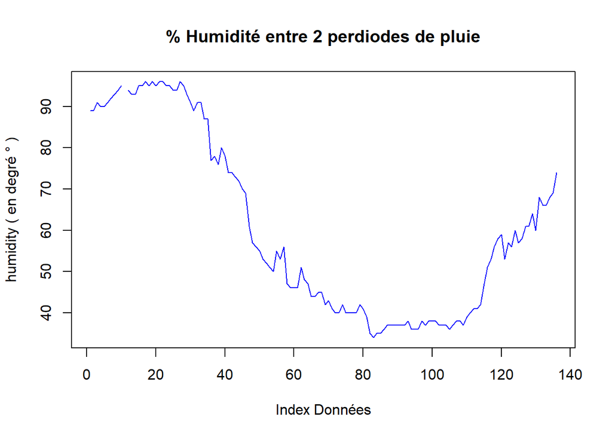

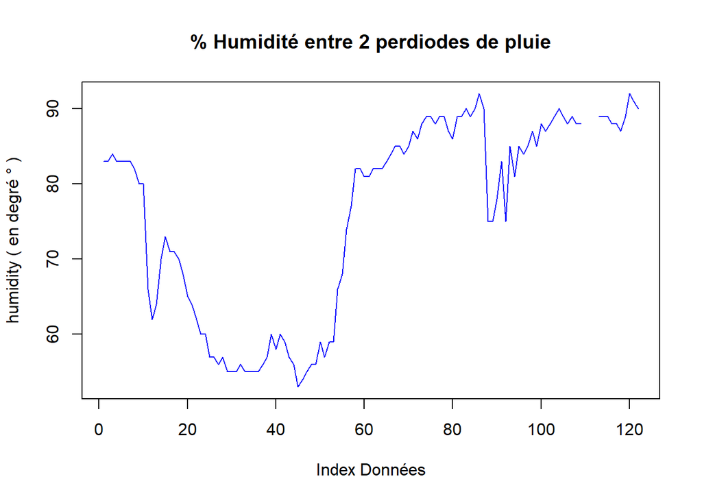

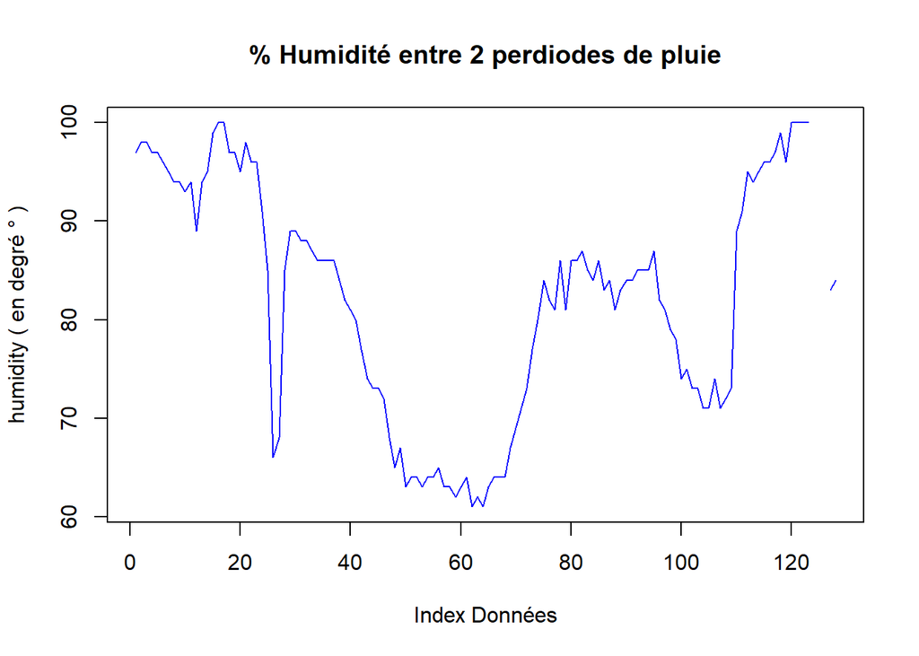

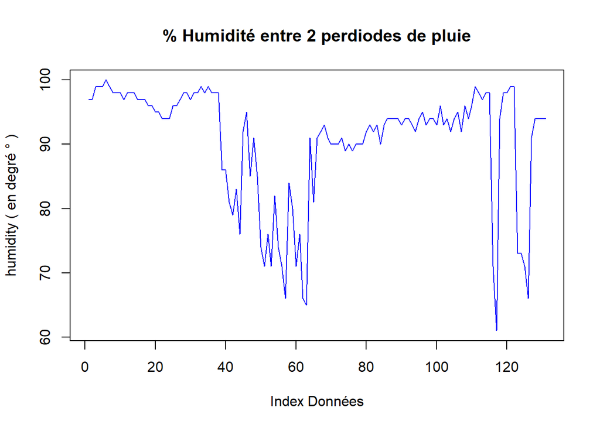

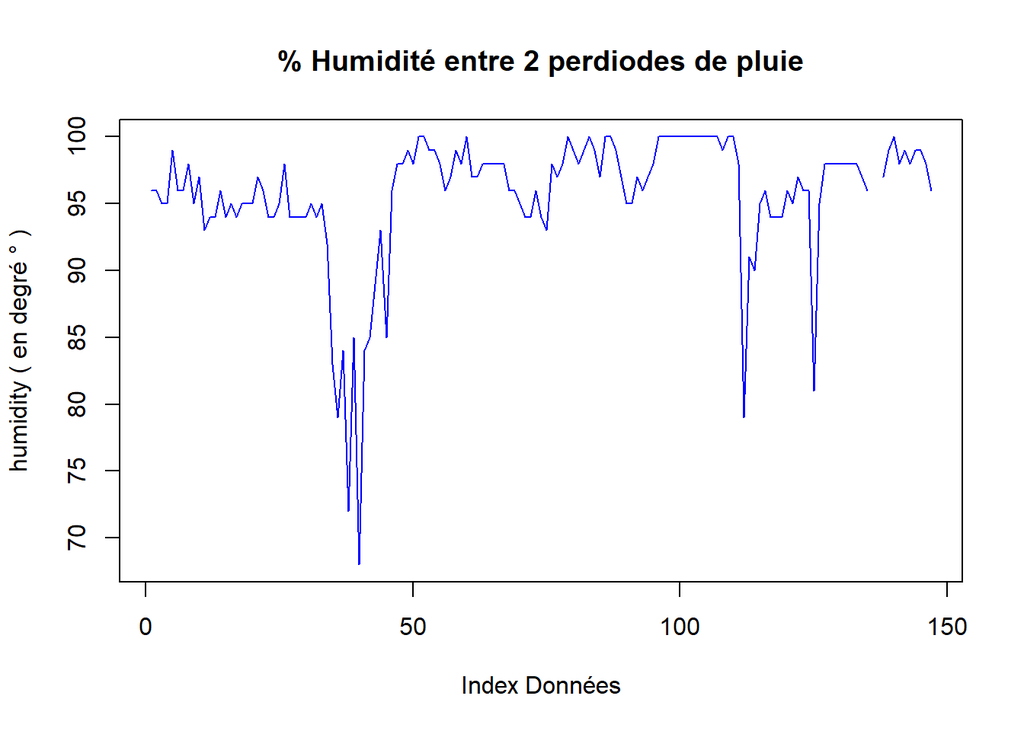

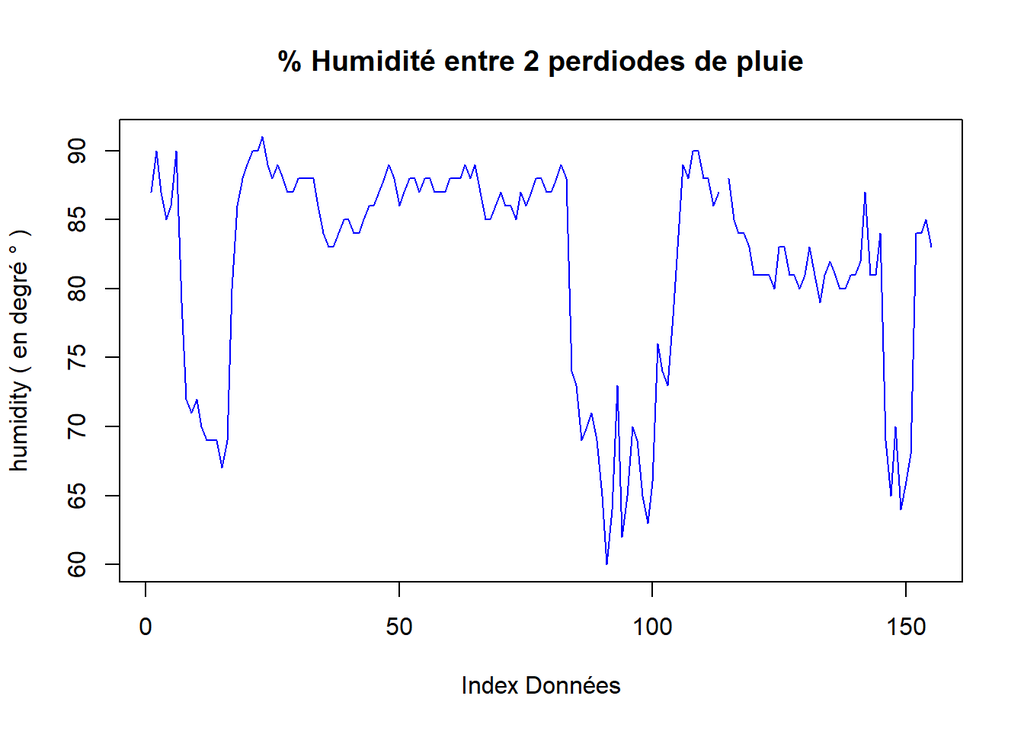

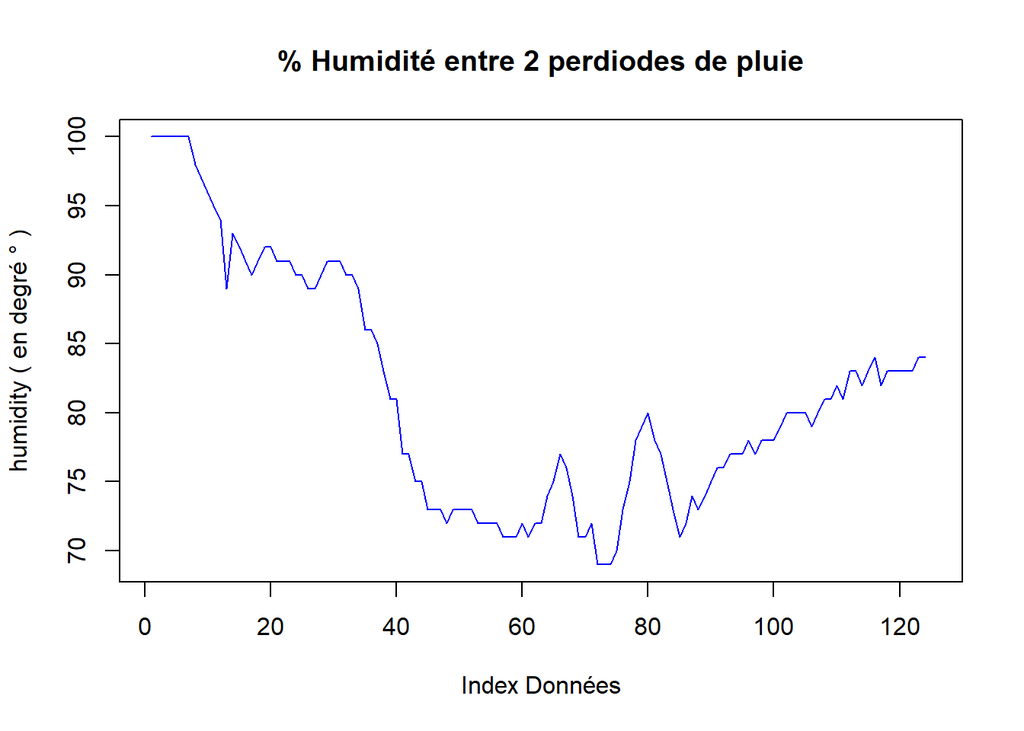

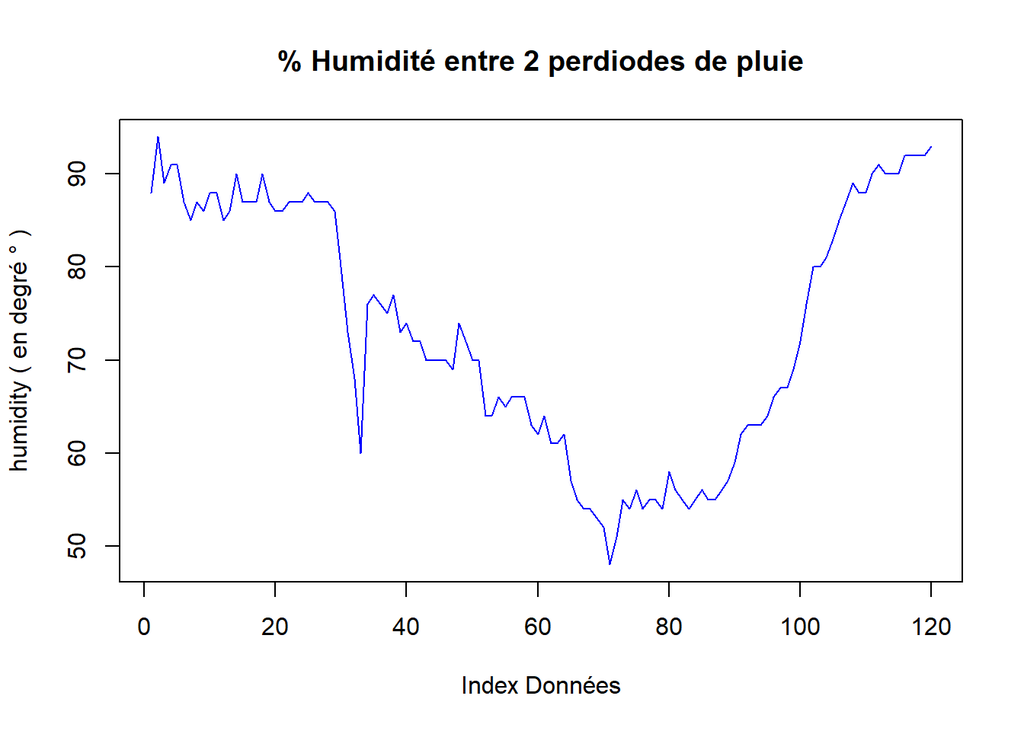

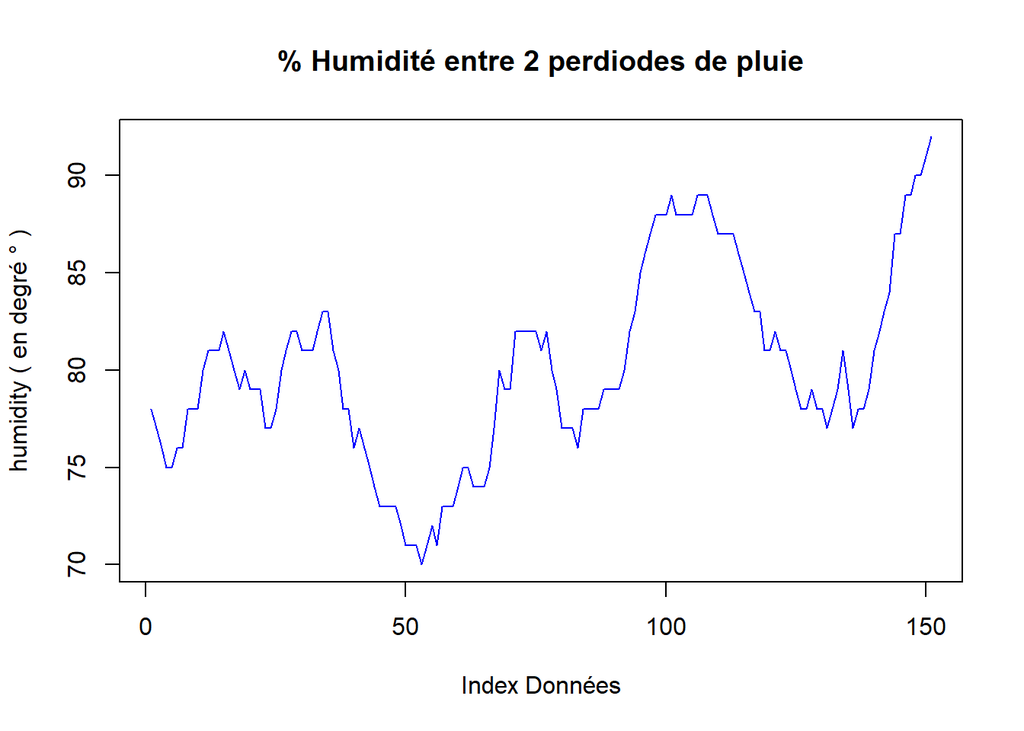

```r
for (elem in newCollection){


    plot( elem[" humidity"], main="% Humidité entre 2 perdiodes de pluie",
          ylab="humidity ( en degré ° )",
          xlab="Index Données",
          type="l",
          col="blue"  )


}
```

On observe que le pourcentage d’humidité est toujours très élevé à la fin d’une période de pluie par contre l’augmentation de se pourcentage ne semble pas toujours mené à une pédiode de pluie.

## Moyenn millieu perdiode sans pluie vs juste avant la pluie

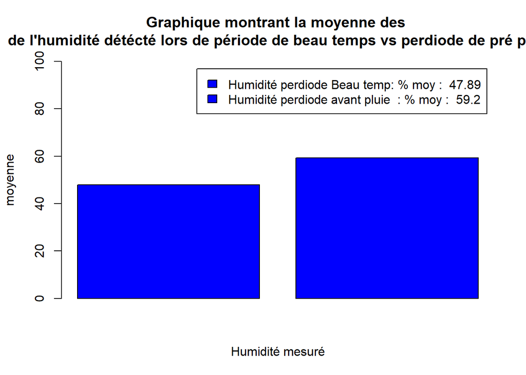

```r
# source_python("C:\\Users\\sburd\\OneDrive\\Bureau\\Semestre2\\Projet_Data\\Stat\\Stat_Projet_Data\\RecupPluieTrue.py")
# monCsv <- openMonCsv("C:\\Users\\sburd\\OneDrive\\Bureau\\Semestre2\\Projet_Data\\DataV2\\dataTrainSorti.csv")
# #heureAdd <- AddHour(monCsv)
# maTabPluie <- trie(monCsv)
# tabDataFrame <- SubsetData(maTabPluie)
# newCollection <- TrieTaille(100,800,tabDataFrame , monCsv)
# TakeDonnePeriode <- MoyenneMidPerdiodeFalsePluieVsBeforePluie(newCollection)
# resMillieu <- resMoyenneMillieu(TakeDonnePeriode[0])
# resBefore <- resMoyenneBefore(TakeDonnePeriode[1])


# {'HumidityM': 47.888888888888886, 'TemperatureM': 23.9, 'PressureM': 1004.0, 'LightM': 529.6666666666666}
# {'HumidityB': 59.2, 'TemperatureB': 22.3, 'PressureB': 1001.4, 'LightB': 153.6}

# vM <- c(round(47.888888888888886,2), round(23.9,2), round(1004.0,2), round(529.6666666666666,2))
# valeurMoyenneMillieu<-as.matrix(vM)
#
# vB <- c(round(59.2,1), round(22.3,1), round(1001.4,1), round(153.6,1))
# valeurMoyenneBefore<-as.matrix(vB)
#
#
# barplotvM <- barplot(vM,
#                        col = c("blue", "green", "yellow", "red"),
#                        legend.text = c(paste("Humidité : % moy : " , round(59.2,2)) ,
#                                        paste("Temperature : température moy : " , round(22.3,2) ,"°C"),
#                                        paste("Pression :  pressions moy" , round(1001.4,2)),
#                                        paste("Lumière :  moy : " , round(153.6,2))
#                                        ),
#                        main = paste("Graphique montrant la moyenne des \n variables détécté lors de période de beau temps"),
#                        ylim = c(0,1010),
#                        xlab = "Varaible mesurées",
#                        ylab = "moyenne"
#
# )
#
#
# barplotvB <- barplot(vB,
#                        col = c("blue", "green", "yellow", "red"),
#                        legend.text = c(paste("Humidité : % moy : " , round(47.888888888888886,2)) ,
#                                        paste("Temperature : température moy : " , round(23.9,2) ,"°C"),
#                                        paste("Pression :  pressions moy" , round(1004.0,2)),
#                                        paste("Lumière :  moy : " , round(529.6666666666666,2))
#                                        ),
#                        main = paste("Graphique montrant la moyenne des \n variables détécté quelque seconde avant un épisode de pluie"),
#                        ylim = c(0,1010),
#                        xlab = "Varaible mesurées",
#                        ylab = "moyenne"
#
# )


barplotvM <- barplot(c(round(47.888888888888886,2) , round(59.2,2)),
                       col = c("blue", "blue"),
                       legend.text = c(paste("Humidité perdiode Beau temp: % moy : " ,round(47.888888888888886,2) ) ,
                                       paste("Humidité perdiode avant pluie  : % moy : " , round(59.2,2))),
                       main = paste("Graphique montrant la moyenne des \n de l'humidité détécté lors de période de beau temps vs perdiode de pré pluie"),
                       ylim = c(0,100),
                       xlab = "Humidité mesuré",
                       ylab = "moyenne"
)
```

[figure not shown]

```r
barplotvM <- barplot(c(23.9 , 22.3),
                       col = c("red", "red"),
                       legend.text = c(paste("température perdiode Beau temp:  moy : " , 23.9 ) ,
                                       paste("Humidité perdiode avant pluie  :  moy : " , 22.3)),
                       main = paste("Graphique montrant la moyenne des \n de la temperature détécté lors de période de beau temps vs perdiode de pré pluie"),
                       ylim = c(15,28),
                       xlab = "temperature mesuré",
                       ylab = "moyenne"
)
```

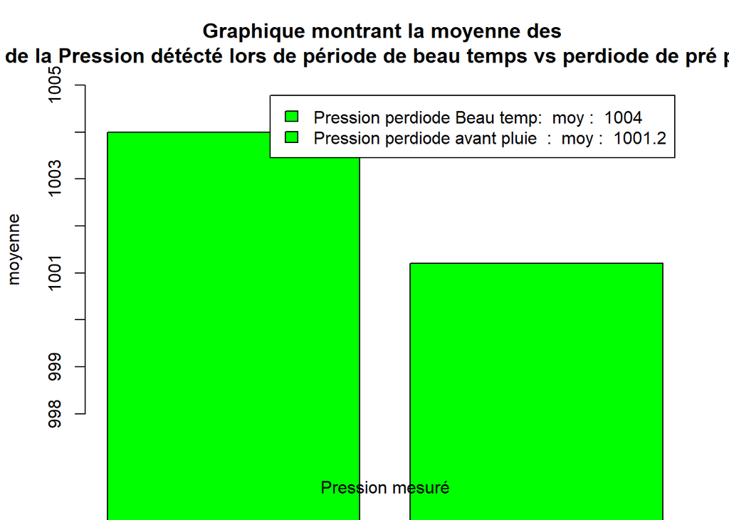

```r
barplotvM <- barplot(c(1004.0 , 1001.2),
                       col = c("green", "green"),
                       legend.text = c(paste("Pression perdiode Beau temp:  moy : " , 1004.0 ) ,
                                       paste("Pression perdiode avant pluie  :  moy : " , 1001.2)),
                       main = paste("Graphique montrant la moyenne des \n de la Pression détécté lors de période de beau temps vs perdiode de pré pluie"),
                       ylim = c(998,1005),
                       xlab = "Pression mesuré",
                       ylab = "moyenne"
)
```

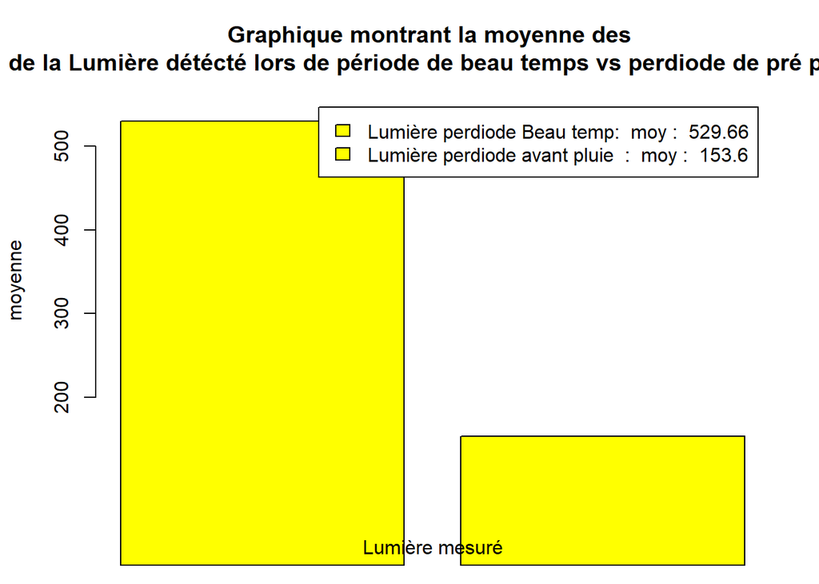

```r
barplotvM <- barplot(c(529.6666666666666 , 153.6),
                       col = c("yellow", "yellow"),
                       legend.text = c(paste("Lumière perdiode Beau temp:  moy : " , 529.66 ) ,
                                       paste("Lumière perdiode avant pluie  :  moy : " , 153.6)),
                       main = paste("Graphique montrant la moyenne des \n de la Lumière détécté lors de période de beau temps vs perdiode de pré pluie"),
                       ylim = c(120,560),
                       xlab = "Lumière mesuré",
                       ylab = "moyenne"
)
```

## Facteur d’humidité en hiver

Nous émetons l’hipothèse que le facteur d’humidité est un facteur annonciateur de la pluie plus conséquent en hiver que pendant les autres saisons.

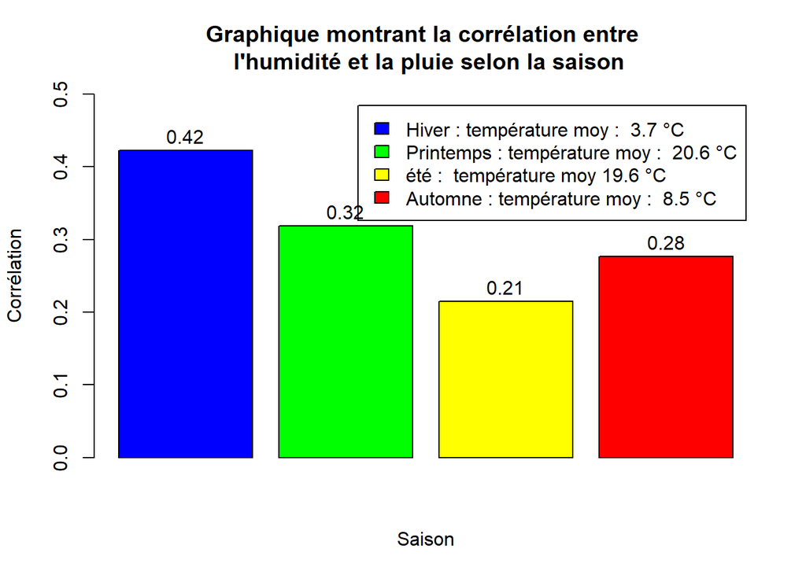

```r
data_meteo_season$month <- strtoi(str_sub(data_meteo$date..date, 7, 8))

data_meteo_season$season<-"summer"
data_meteo_season$season[data_meteo_season$month>9&data_meteo_season$month<=12]<-"autumn"
data_meteo_season$season[data_meteo_season$month>1&data_meteo_season$month<=3]<-"winter"
data_meteo_season$season[data_meteo_season$month>3&data_meteo_season$month<=6]<-"spring"
data_meteo_season$season<-factor(data_meteo_season$season,levels=c("summer","spring","winter","autumn"))


summer <- filter(data_meteo_season, season == "summer", rain != "NA", humidity != "NA", temperature != "NA")
autumn <- filter(data_meteo_season, season == "autumn", rain != "NA", humidity != "NA",  temperature != "NA")
spring <- filter(data_meteo_season, season == "spring", rain != "NA", humidity != "NA",  temperature != "NA")
winter <- filter(data_meteo_season, season == "winter", rain != "NA", humidity != "NA",  temperature != "NA")

corWin = cor( winter$humidity, winter$rain, method=c("pearson", "kendall", "spearman")) #0.4774225
corSum = cor( summer$humidity, summer$rain, method=c("pearson", "kendall", "spearman")) #0.2675425
corAut = cor( autumn$humidity, autumn$rain, method=c("pearson", "kendall", "spearman")) #0.313826
corSpr = cor( spring$humidity, spring$rain, method=c("pearson", "kendall", "spearman")) #  0.3957939




CorSaisVal<-as.matrix(c(corWin, corSpr, corSum, corAut))



barplotsais <- barplot(c(corWin, corSpr, corSum, corAut),
                       col = c("blue", "green", "yellow", "red"),
                       legend.text = c(paste("Hiver : température moy : " , round(mean(winter$temperature), 1),"°C") ,
                                       paste("Printemps : température moy : " , round(mean(spring$temperature), 1),"°C"),
                                       paste("été :  température moy" , round(mean(summer$temperature), 1),"°C"),
                                       paste("Automne : température moy : " , round(mean(autumn$temperature), 1),"°C")
                                       ),
                       main = paste("Graphique montrant la corrélation entre \n l'humidité et la pluie selon la saison"),
                       ylim = c(0,0.5),
                       xlab = "Saison",
                       ylab = "Corrélation"

)

text(barplotsais ,CorSaisVal+0.02,labels=round(CorSaisVal,2))
```

À partir de ces résultats, nous pourrons donner plus d’importances à la valeur d’humidité selon la saison et selon la température.

## Le cycle jour/nuit jour sur la pluie

Nous émétons l’hypothèse que la nuit est un facteur annonciateur de la pluie.

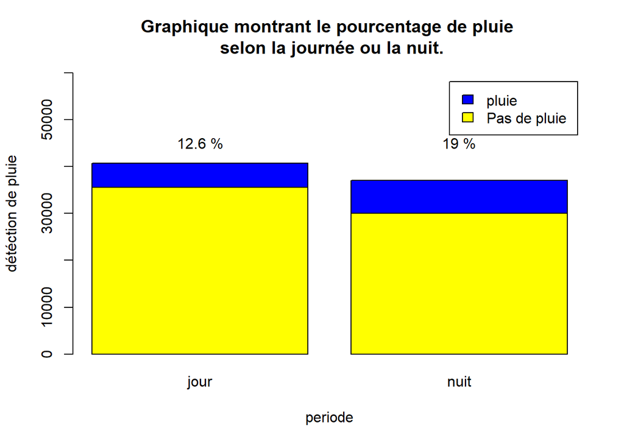

```r
data_meteo_rain <- data_meteo
data_meteo_rain <- filter(data_meteo_rain, rain != "NA" & light != "NA")

data_meteo_rain$pluie[data_meteo_rain$rain>0]<-"oui"
data_meteo_rain$pluie[data_meteo_rain$rain==0]<-"non"
data_meteo_rain$jour[data_meteo_rain$light>0]<-"jour"
data_meteo_rain$jour[data_meteo_rain$light==0]<-"nuit"

data_meteo_jour <- filter(data_meteo_rain, jour == "jour")
data_meteo_nuit <- filter(data_meteo_rain, jour == "nuit")

effectifsjour <- table(data_meteo_jour$pluie)
racajour=prop.table(effectifsjour) * 100
effectifsnuit <- table(data_meteo_nuit$pluie)
racanuit=prop.table(effectifsnuit) * 100

pcrjp7<-as.matrix(c(racajour["oui"],  racanuit["oui"]))
pcrjp<-as.matrix(c(pcrjp7[1], pcrjp7[2]))


barplotjp = barplot(table(data_meteo_rain$pluie, data_meteo_rain$jour),
        col = c("yellow", "blue"),
        legend.text = c(paste("Pas de pluie ") ,
                        paste("pluie ")
        ),
        main = paste("Graphique montrant le pourcentage de pluie \n selon la journée ou la nuit."),
        ylim = c(0,60000),
        xlab = "periode",
        ylab = "détéction de pluie"
        )

text(barplotjp ,pcrjp+45000,labels=as.character(paste(round(pcrjp,1),"%")))
```

L’hypothèse signifiant que le le jour ou la nuit sont des facteurs plus conséquents, est donc fausse malgré le fait que nous avons une petite augmentation de pluie la nuit.

D’après ces résultats, nous savons que le cycle jour nuit n’est pas un facteur assez déterminant pour le prendre en compte lors de la mise en place de l’algorithme de détection de pluie.

# Prediction de l’apparition de la pluie ( DS ):

Pour prédire le plus présicement possible l’arrivée de la pluie nous avons choisi d’utiliser l’algorythme knn . Il permet d’analyser un grand nombre de données efficassement et de faire ressortir les données enregistrer précedement les plus proches de celle mesuré actuellement .

Nous avons impleté cet algorythme en python . Cet algorythme se base sur un jeu de ~80 000 données d’entrainnement et nous observerons les 10 plus proches voisins des X dernières données enregistrer .

Pour eviter de selectionner les données chronologiquement voisinnes nous retirons les 4200 données précédents les mesures. Ce qui correspond environs au mois précédent.

Les données d’entrainement etant au format json nous choisissons de convertir au format csv pour facilité leurs traitements. Après transfomation du json en csv le format des données est celui-ci.

```r
Exemple_Donnee  <- tibble::tribble(
    ~X_id, ~humidity, ~date..date, ~pressure, ~Temperature, ~rain, ~light, ~t , ~PS ,
  "04_27_2017_03_08", "67", "2017-04-27T06:08:36.000+0300" ,"1007 ",  "11" ,"0",  "0", NA, NA,
  )

require(rhandsontable)
rhandsontable(Exemple_Donnee , rowHeaders = NULL,
               digits = 3, useTypes = FALSE, search = FALSE,
               width = NULL, height = NULL)
```

[interactive table not shown]

Le donnée sont maintenant de ce format :

```r
Exemple_Donnee  <- tibble::tribble(
    ~X_id, ~humidity, ~date..date, ~pressure, ~Temperature, ~light,~rain ,
  "116", "67", "116" ,"1007 ",  "11" ,"0",  "0",
  )

require(rhandsontable)
rhandsontable(Exemple_Donnee , rowHeaders = NULL,
               digits = 3, useTypes = FALSE, search = FALSE,
               width = NULL, height = NULL)
```

[interactive table not shown]

On décide aussi de remplacer les valeur de pluie par 1 si elle sont >= 1 , pour avoir une meilleur différence entre les période de beau temps et les période pluie .

Maintenant nous pouvons commencer à traiter les données dans l’alogrythme Knn . Pour ce faire nous avons comme dis précédement les 80 000 données de train et nous prennons pour commmencer les 10 dernières donnes piur creer les donnes de tests. Soit :

```r
Exemple_Donnee_test  <- tibble::tribble(
  ~X_id, ~humidity, ~date..date, ~pressure, ~Temperature, ~light,~rain ,
  "22",   "85" ,"22",   "1000" ,  " 1" ,   "0" ,   "0" ,
  "22",   "84" ,"22",   "1000" ,  " 1" ,   "0" ,   "0" ,
  "22",   "86" ,"22",   "1000" ,  " 1" ,   "0" ,   "0" ,
  "22",   "84" ,"22",   "1000" ,  " 1" ,   "0" ,   "0" ,
  "22",   "84" ,"22",   "1000" ,  " 1" ,   "0" ,   "0" ,
  "22",   "85" ,"22",   "999" ,  " 1" ,   "0" ,   "0" ,
  "22",   "85" ,"22",   "999" ,  " 1" ,   "0" ,   "0" ,
  "22",   "85" ,"22",   "999" ,  " 1" ,   "0" ,   "0" ,
  "22",   "86" ,"22",   "999" ,  " 1" ,   "0" ,   "0" ,
  "22",   "85" ,"22",   "999" ,  " 1" ,   "0" ,   "0" ,
  )

require(rhandsontable)
rhandsontable(Exemple_Donnee_test , rowHeaders = NULL,
               digits = 3, useTypes = FALSE, search = FALSE,
               width = NULL, height = NULL)
```

[interactive table not shown]

Pour ces données de test , nous lançons l’algorythme Knn avec, pour commmencer, 10 voisins. Pour chaque ligne testé on trouve d’abord un index des 10 voisins les plus proches

```r
my_tbl <- tibble::tribble(
  ~Indexvoisin1 ,~Indexvoisin2 ,~Indexvoisin3 ,~Indexvoisin4 ,~Indexvoisin5 ,~Indexvoisin6 ,~Indexvoisin7 ,~Indexvoisin8 ,~Indexvoisin9 ,~Indexvoisin10,
  "31697", "31713" ,"31711", "31714" ,"31710", "31712", "31702" ,"31704", "31706" ,"31720",
  "31697" ,"31713" ,"31711", "31710", "31706" ,"31704", "31712" ,"31702" ,"31703", "31714",
  "31697" ,"31713", "31711" ,"31714", "31717", "31720", "31719", "31718", "31722" ,"31710",
  "31697", "31713", "31711" ,"31710", "31706", "31704", "31712", "31702" ,"31703", "31714",
  "31697", "31713", "31711" ,"31710", "31706", "31704", "31712", "31702", "31703", "31714",
  "31713", "31711", "31697", "31714", "31710", "31712", "31720", "31719", "31718", "31722",
  "31713", "31711", "31697" ,"31714", "31710", "31712", "31720", "31719", "31718", "31722",
  "31713", "31711", "31697" ,"31714", "31710", "31712", "31720", "31719", "31718", "31722",
  "31711", "31713", "31714", "31717", "31720", "31719", "31722", "31718", "31697", "31716",
  "31713" ,"31711", "31697", "31714","31710", "31712", "31720", "31719", "31718", "31722",
  )

require(rhandsontable)
rhandsontable(my_tbl, rowHeaders = NULL,
               digits = 3, useTypes = FALSE, search = FALSE,
               width = NULL, height = NULL)
```

[interactive table not shown]

Ensuite on regarde a chaqu’un de ses indices de chaque ligne leur valeur pour l’attribut pluie , qui peut etre pour rappel soit 0 (absence de pluie) soit 1 ( presence de pluie).

il se trouve que dans ce cas présis tout les indices ont une valeur de 0 , donc on en débuit que la valeur de prédiction à retourné est de 0 = absence de pluie.

Dans le cas ou la valeur des attridus pluie n’est pas que de 0 ou que de 1 , on regarde quelle valeur est le plus représenté et on la retourne .

```{ r stat}

```